# Replicación Edmonson 1999

Equipo 2

Cademi

Data (Por el momento estara cargada en este apartado).

```
## Rows: 48
## Columns: 26
## $ equipoID              <int> 1032, 1045, 1060, 1087, 1109, 1140, 1152, 116...
## $ performance1          <int> 2, 3, 3, 3, 4, 2, 2, 3, 3, 3, 3, 2, 4, 3, 3, ...
## $ performance2          <int> 3, 3, 4, 4, 4, 3, 2, 3, 4, 4, 4, 2, 4, 3, 3, ...
## $ performance3          <int> 2, 3, 3, 3, 4, 2, 3, 3, 3, 3, 4, 1, 4, 3, 3, ...
## $ performance4          <int> 3, 3, 4, 3, 3, 2, 3, 3, 4, 3, 3, 2, 2, 4, 3, ...
## $ psycsafe1             <dbl> 5.00, 5.00, 5.00, 4.60, 5.00, 4.86, 5.00, 5.0...
## $ psycsafe2             <dbl> 2.40, 3.00, 4.00, 4.20, 4.60, 4.14, 3.20, 3.2...
## $ psycsafe3             <dbl> 5.00, 5.00, 5.00, 5.00, 5.00, 4.57, 5.00, 5.0...
## $ psycsafe4             <dbl> 4.40, 4.57, 4.50, 4.40, 4.40, 4.14, 4.60, 4.5...
## $ psycsafe5             <dbl> 4.60, 5.00, 4.75, 5.00, 4.80, 4.57, 5.00, 5.0...
## $ psycsafe6             <dbl> 3.20, 3.43, 5.00, 4.20, 4.00, 3.86, 2.60, 3.2...
## $ psycsafe7             <dbl> 4.40, 4.43, 4.50, 4.60, 4.60, 4.14, 4.80, 4.7...
## $ learnbehavior1        <dbl> 3.50, 3.17, 4.00, 3.33, 3.75, 3.80, 3.00, 4.2...
## $ learnbehavior2        <dbl> 2.83, 3.50, 2.00, 2.50, 2.75, 2.40, 3.40, 2.8...
## $ learnbehavior3        <dbl> 3.33, 3.33, 3.75, 2.17, 2.75, 2.20, 2.40, 3.0...
## $ learnbehavior4        <dbl> 3.83, 3.67, 4.25, 3.17, 3.75, 3.80, 3.40, 4.2...
## $ learnbehavior5        <dbl> 3.67, 3.83, 4.00, 3.33, 3.75, 3.80, 3.40, 4.2...
## $ learnbehavior6        <dbl> 3.83, 3.67, 3.75, 3.83, 3.75, 4.40, 3.40, 4.6...
## $ learnbehavior7        <dbl> 1.83, 2.00, 1.50, 2.83, 2.25, 2.00, 1.80, 2.6...
## $ efficacy1             <dbl> 4.67, 4.33, 4.75, 4.33, 4.50, 4.20, 4.20, 4.6...
## $ efficacy2             <dbl> 4.50, 4.67, 4.25, 4.33, 4.50, 4.00, 4.20, 4.2...
## $ efficacy3             <dbl> 4.17, 4.33, 4.00, 3.83, 4.00, 4.20, 3.80, 4.4...
## $ teamsatisfaction1     <dbl> 4.50, 4.83, 5.00, 3.83, 4.75, 4.60, 3.40, 5.0...
## $ teamsatisfaction2     <dbl> 4.33, 4.67, 5.00, 3.50, 4.75, 4.20, 3.60, 4.8...
## $ teamsatisfaction3     <dbl> 4.50, 4.50, 5.00, 4.00, 4.50, 4.60, 3.40, 5.0...
## $ teamteamsatisfaction2 <dbl> 4.33, 4.67, 5.00, 3.50, 4.75, 4.20, 3.60, 4.8...
```

## Methods.

Para poner a prueba las hipotesis evaluadas en este trabajo, seguimos la metodologia de Edmonson (1999). El objetivo principal fue medir seguridad psicologica en los distintos grupos.

Estudiamos la interacción entre los estudiantes de primer año de la carrera de *Ingenieria Comercial* del año 2020, de la *Universidad Diego Portales*. Medimos datos cuantitativos respecto al curso *Fundamentos de Administracion y Negocios*. Las encuestas fueron realizadas durante un lapso de 5 meses, en distintos periodos de tiempo. Estas se realizaron a traves de los docentes del curso, los cuales nos ayudaron tambien a la confeccion de las escalas y tipos de medidas. El total de estudiantes evaluados fue de 280 aproximadamente. Se trabajo en grupos pequeños de 5 a 6 estudiantes. Se recopilaron 48 equipos en total, los cuales fueron evaluados en conjunto durante todo el proceso, sin ninguna modificacion o salida de alguno de estos a lo largo del periodo establecido.

Al ser un curso de primer año universitario, ninguno de los participantes tenia conocimientos teoricos previos en cuanto a trabajo en equipo, liderazgo o administracion. Ademas, recalcar que ninguno de los estudiantes mantenia una relacion estrecha entre sus pares o academicos de la facultad, previa la investigacion realizada. El unico medio de interaccion que tuvimos con los estudiantes a lo largo del proyecto fueron netamente las respuestas otorgadas a traves de las encuestas.

### Process

Posterior a eso, analizamos los datos provenientes a las respuestas. Medimos el nivel de consistencia de las preguntas via el Alfa de Chronbach. Para esto, diseñamos un algoritmo que expulsara las preguntas que provocaran un Alfa de Chronbach inferior a 0.7.

```r
#1) Psysafety

psysafe <- data %>%
  select(starts_with("psy"))
lim <- 0.7

eliminacion <- 0

while ( eliminacion < lim ) {

  alfa <- alpha(psysafe)
  alfa_raw <- alfa$total$raw_alpha

  alfa_drop <- alfa$alpha.drop %>%
    as.data.frame()

  # Strategy
  eliminacion <- alfa_drop %>%
    select(raw_alpha)%>%
    filter(alfa_raw < raw_alpha)%>%
    row.names()%>%
    head(1)
  psysafe <- psysafe %>%
    select(-eliminacion)
  #

}

psysafe_select <- colnames(psysafe)

psysafe <- data %>%
  select(equipoID, all_of(psysafe_select))%>%
  pivot_longer(-equipoID)%>%
  group_by(equipoID)%>%
  summarize(psysafe=round(mean(value),2))

#2)Learn Behavior

learnb <- data %>%
  select(starts_with("learn"))

eliminacion <- 0

while ( eliminacion < lim ) {

  alfa <- alpha(learnb)
  alfa_raw <- alfa$total$raw_alpha

  alfa_drop <- alfa$alpha.drop %>%
    as.data.frame()

  # Strategy
  eliminacion <- alfa_drop %>%
    select(raw_alpha)%>%
    filter(alfa_raw < raw_alpha)%>%
    row.names()%>%
    head(1)
  learnb <- learnb %>%
    select(-eliminacion)
  #

}

learnb_select <- colnames(learnb)

learnb <- data %>%
  select(equipoID, all_of(learnb_select))%>%
  pivot_longer(-equipoID)%>%
  group_by(equipoID)%>%
  summarize(learnbehavior=round(mean(value),2))

#3)Efficacy

efficacy <- data %>%
  select(starts_with("eff"))

eliminacion <- 0

while ( eliminacion < lim ) {

  alfa <- alpha(efficacy)
  alfa_raw <- alfa$total$raw_alpha

  alfa_drop <- alfa$alpha.drop %>%
    as.data.frame()

  # Strategy
  eliminacion <- alfa_drop %>%
    select(raw_alpha)%>%
    filter(alfa_raw < raw_alpha)%>%
    row.names()%>%
    head(1)
  efficacy <- efficacy %>%
    select(-eliminacion)
  #

}
efficacy_select <- colnames(efficacy)

efficacy <- data %>%
  select(equipoID, all_of(efficacy_select) )%>%
  pivot_longer(-equipoID)%>%
  group_by(equipoID)%>%
  summarize(efficacy=round(mean(value),2))

#4) Team Satisfaction

team_s <- data %>%
  select(starts_with("team"))

eliminacion <- 0

while ( eliminacion < lim ) {

  alfa <- alpha(team_s)
  alfa_raw <- alfa$total$raw_alpha

  alfa_drop <- alfa$alpha.drop %>%
    as.data.frame()

  # Strategy
  eliminacion <- alfa_drop %>%
    select(raw_alpha)%>%
    filter(alfa_raw < raw_alpha)%>%
    row.names()%>%
    head(1)
  team_s <- team_s %>%
    select(-eliminacion)
  #

}
team_s_select <- colnames(team_s)

team_s <- data %>%
  select(equipoID, all_of(team_s_select) )%>%
  pivot_longer(-equipoID)%>%
  group_by(equipoID)%>%
  summarize(teamsatisfaction=round(mean(value),2))

#5)Performance

performance <- data %>%
  select(equipoID, starts_with("per"))%>%
  pivot_longer(-equipoID)%>%
  group_by(equipoID)%>%
  summarize(performance=round(mean(value),2))
```

Junto con lo anterior, agregamos las variables que fueron medidas en distintas preguntas.

```
## Rows: 48
## Columns: 6
## $ equipoID         <int> 1032, 1045, 1060, 1087, 1109, 1140, 1152, 1160, 11...
## $ performance      <dbl> 2.50, 3.00, 3.50, 3.25, 3.75, 2.25, 2.50, 3.00, 3....
## $ psysafe          <dbl> 4.00, 4.24, 4.62, 4.57, 4.57, 4.24, 4.20, 4.29, 4....
## $ teamsatisfaction <dbl> 4.42, 4.67, 5.00, 3.71, 4.69, 4.40, 3.50, 4.90, 4....
## $ learnbehavior    <dbl> 3.33, 3.28, 3.54, 3.11, 3.33, 3.33, 2.90, 3.80, 4....
## $ efficacy         <dbl> 4.58, 4.50, 4.50, 4.33, 4.50, 4.10, 4.20, 4.40, 4....
```

Examinamos como correlacionan las variables:

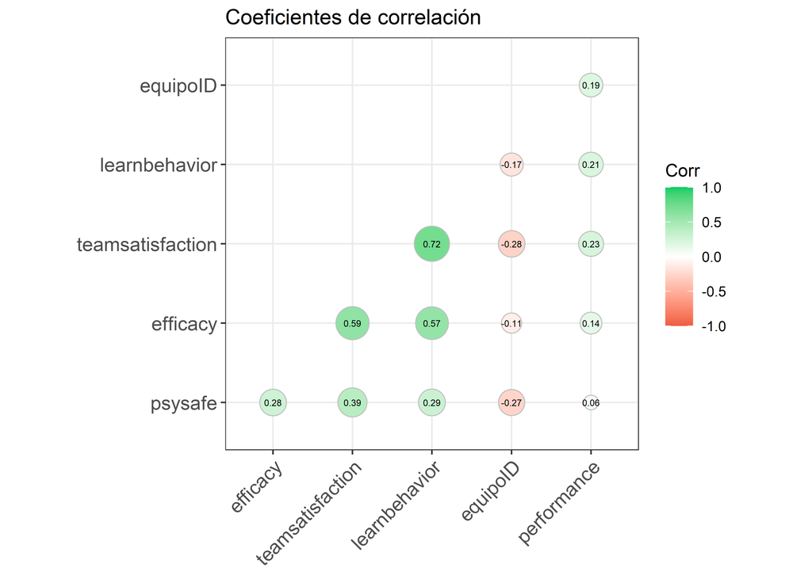

## Results.

## Discussion.

## Conclusion.

## References.